# Obesidad

Marcos López García, Carmen Liberal Jiménez y Lara Montero del Prado

2025-03-11

# 0. Introducción.

Este conjunto de datos contienen la información para dar una estimación de los niveles de obesidad de personas residentes en Mexico, Perú y Colombia.

Estos datos se han adquirido de [repositorio de datos de kaggle](https://www.kaggle.com/datasets/aravindpcoder/obesity-or-cvd-risk-classifyregressorcluster). Segun la descripción del repositorio, nos basamos en personas con edades entre 14 y 61 años y diversos hábitos alimenticios y condición física. Estos datos se han recolectado mediante una plataforma web con una encuesta donde usuarios anónimos respondieron cada pregunta.

En este dataset podemos encontrar distintos tipos de variables:

- Gender: Genero.
- Age: Edad.
- Height: Altura (m).
- Weight: Peso (kg).
- family_history_with_overweight: Antecedentes familiares.
- FAVC: Consumo frecuente de alimentos de alto valor genético.
- FCVC: Frecuencia de consumo deverduras.
- NCP: Número de comidas principales.
- CAEC: Consumo de alimentos entre comidas.
- CH2O: Consumo de agua diariamente.
- CALC: Consumo de alcohol.
- SCC: Monitoreo del consumo de calorías.
- FAF: Frecuencias de actividad física.
- TUE: Tiempo utilizado dispositivos electronicos.
- MTRANS: Transporte utilizado con frecuencia.
- NObeyesdad: Grupos segun el nivel de obesidad, se diferencian en:
  - Bajo peso: Menos de 18,5.
  - Normal: 18,5 a 24,9.
  - Sobrepeso: 25,0 a 29,9.
  - Obesidad I: 30,0 a 34,9.
  - Obesidad II: 35,0 a 39,9.
  - Obesidad III: Mayor de 40.

# 1. Data understanding.

Primero de todo, vamos a cargar los datos y vamos a ver la cantidad de variables y observaciones que encontramos.

```r
obesidad <- read.csv("C:/Users/laram/Downloads/archive (3)/ObesityDataSet.csv")
data <- dim(obesidad)
```

Podemos observar que tenemos una cantiadad de 2111 observaciones y 17 variables en este dataset

En estos datos, las varibles son de distintos tipos:

```r
str(obesidad)
```

```
## 'data.frame':    2111 obs. of  17 variables:
##  $ Gender                        : chr  "Female" "Female" "Male" "Male" ...
##  $ Age                           : num  21 21 23 27 22 29 23 22 24 22 ...
##  $ Height                        : num  1.62 1.52 1.8 1.8 1.78 1.62 1.5 1.64 1.78 1.72 ...
##  $ Weight                        : num  64 56 77 87 89.8 53 55 53 64 68 ...
##  $ family_history_with_overweight: chr  "yes" "yes" "yes" "no" ...
##  $ FAVC                          : chr  "no" "no" "no" "no" ...
##  $ FCVC                          : num  2 3 2 3 2 2 3 2 3 2 ...
##  $ NCP                           : num  3 3 3 3 1 3 3 3 3 3 ...
##  $ CAEC                          : chr  "Sometimes" "Sometimes" "Sometimes" "Sometimes" ...
##  $ SMOKE                         : chr  "no" "yes" "no" "no" ...
##  $ CH2O                          : num  2 3 2 2 2 2 2 2 2 2 ...
##  $ SCC                           : chr  "no" "yes" "no" "no" ...
##  $ FAF                           : num  0 3 2 2 0 0 1 3 1 1 ...
##  $ TUE                           : num  1 0 1 0 0 0 0 0 1 1 ...
##  $ CALC                          : chr  "no" "Sometimes" "Frequently" "Frequently" ...
##  $ MTRANS                        : chr  "Public_Transportation" "Public_Transportation" "Public_Transportation" "Walking" ...
##  $ NObeyesdad                    : chr  "Normal_Weight" "Normal_Weight" "Normal_Weight" "Overweight_Level_I" ...
```

Podemos ver como hay distintos tipos de variables en los datos, en el cual solo hay dos tipos, el tipo numérico `num` (`Age`, `Height`, `Weight`, `FCVV`, `NCP`, `CH2O`, `FAF`Y `TUE`) y por otro lado, tenemos vectores de caracteres `char` (`Gender`, `family_history_with_overweight`, `FAVC`, `CAEC`, `SMOKE`, `SSC`, `CALC`, `MTRANS`, `NObeyesdad`)

Antes de hacer la partición de los datos para hacer un mejor análisis, vamos a observar si hay valores faltantes.

```r
colSums(is.na(obesidad))
```

```
##                         Gender                            Age
##                              0                              0
##                         Height                         Weight
##                              0                              0
## family_history_with_overweight                           FAVC
##                              0                              0
##                           FCVC                            NCP
##                              0                              0
##                           CAEC                          SMOKE
##                              0                              0
##                           CH2O                            SCC
##                              0                              0
##                            FAF                            TUE
##                              0                              0
##                           CALC                         MTRANS
##                              0                              0
##                     NObeyesdad
##                              0
```

Podemos observar que no hay variables de tipo NA, por lo que no es necesario hacer algún tipo de imputación sobre los datos para hacer el análisis de los datos. Vemos que en la variables hay ciertos valores que no tiene mucho sentido, como por ejemplo que el número de comidas principales tenga decimales y otras más, por ello vamos a corregir esoso errores.

```r
obesidad$Age <- round(obesidad$Age)
obesidad$NCP <- round(obesidad$NCP)
obesidad$FAF <- round(obesidad$FAF)
```

Realizamos la partición de nuestros datos.

```r
set.seed(1)

# Indices para la partición
nobesidad <- dim(obesidad)[1]
indices <- 1:nobesidad
ntrain <- nobesidad * 0.6
indices.train <- sample(indices, ntrain, replace = FALSE)
indices.test_val <- indices[-indices.train]

# Usamos el 60% para las variables de entrenamiento
train <- obesidad[indices.train, ]
test_val <- obesidad[indices.test_val, ]

# Creamos los indices para test y para val
ntest_val <- dim(test_val)[1]
indices = 1:ntest_val
ntest <-  ntest_val * 0.5
indices.test <- sample(indices, ntest, replace = FALSE)
indices.val <- indices[-indices.test]

# Creamos los datos de test y val
test <- test_val[indices.test, ]
val <- test_val[indices.val, ]
```

Miramos la información de nuestros datos de entrenamiento

```r
dim(train)
```

```
## [1] 1266   17
```

```r
head(train)
```

```
##      Gender Age   Height    Weight family_history_with_overweight FAVC     FCVC
## 1017   Male  18 1.654757  80.00000                            yes  yes 2.821977
## 679  Female  20 1.667404  49.12595                             no   no 2.880792
## 930    Male  22 1.698049  75.00000                            yes  yes 2.000000
## 1533   Male  23 1.841989 122.02495                            yes  yes 3.000000
## 471  Female  20 1.560000  51.50000                             no  yes 2.000000
## 270    Male  23 1.720000  66.00000                            yes  yes 2.000000
##      NCP       CAEC SMOKE     CH2O SCC FAF      TUE      CALC
## 1017   2  Sometimes    no 1.954968  no   1 0.854536        no
## 679    3  Sometimes    no 1.960131  no   2 1.000000 Sometimes
## 930    3  Sometimes    no 2.763573  no   2 0.127879 Sometimes
## 1533   3  Sometimes    no 1.645338  no   1 0.000000 Sometimes
## 471    3 Frequently    no 2.000000  no   3 0.000000 Sometimes
## 270    3  Sometimes    no 2.000000  no   0 1.000000 Sometimes
##                     MTRANS          NObeyesdad
## 1017 Public_Transportation Overweight_Level_II
## 679  Public_Transportation Insufficient_Weight
## 930  Public_Transportation  Overweight_Level_I
## 1533 Public_Transportation     Obesity_Type_II
## 471  Public_Transportation       Normal_Weight
## 270                Walking       Normal_Weight
```

```r
str(train)
```

```
## 'data.frame':    1266 obs. of  17 variables:
##  $ Gender                        : chr  "Male" "Female" "Male" "Male" ...
##  $ Age                           : num  18 20 22 23 20 23 26 17 23 20 ...
##  $ Height                        : num  1.65 1.67 1.7 1.84 1.56 ...
##  $ Weight                        : num  80 49.1 75 122 51.5 ...
##  $ family_history_with_overweight: chr  "yes" "no" "yes" "yes" ...
##  $ FAVC                          : chr  "yes" "no" "yes" "yes" ...
##  $ FCVC                          : num  2.82 2.88 2 3 2 ...
##  $ NCP                           : num  2 3 3 3 3 3 3 4 1 3 ...
##  $ CAEC                          : chr  "Sometimes" "Sometimes" "Sometimes" "Sometimes" ...
##  $ SMOKE                         : chr  "no" "no" "no" "no" ...
##  $ CH2O                          : num  1.95 1.96 2.76 1.65 2 ...
##  $ SCC                           : chr  "no" "no" "no" "no" ...
##  $ FAF                           : num  1 2 2 1 3 0 2 2 1 2 ...
##  $ TUE                           : num  0.855 1 0.128 0 0 ...
##  $ CALC                          : chr  "no" "Sometimes" "Sometimes" "Sometimes" ...
##  $ MTRANS                        : chr  "Public_Transportation" "Public_Transportation" "Public_Transportation" "Public_Transportation" ...
##  $ NObeyesdad                    : chr  "Overweight_Level_II" "Insufficient_Weight" "Overweight_Level_I" "Obesity_Type_II" ...
```

# 2. EDA.

Vamos a comenzar con nuestro Análisis Exploratorio de Datos, que ayudará a comprender la estructura, distribución y relaciones de nuestras variables con los niveles de obesidad.

Mediante una tabla de frecuencias, vamos a observar como se distribuye cada tipo de obesidad en nuestros datos

```r
tabla_frecuencias <- train |>
  count(NObeyesdad) |>
  mutate(f = n/nrow(train),
         N = cumsum(n),
         F = cumsum(f))

knitr::kable(tabla_frecuencias, digits = 4)
```

| NObeyesdad | n | f | N | F |
| --- | --- | --- | --- | --- |
| Insufficient_Weight | 161 | 0.1272 | 161 | 0.1272 |
| Normal_Weight | 196 | 0.1548 | 357 | 0.2820 |
| Obesity_Type_I | 199 | 0.1572 | 556 | 0.4392 |
| Obesity_Type_II | 177 | 0.1398 | 733 | 0.5790 |
| Obesity_Type_III | 188 | 0.1485 | 921 | 0.7275 |
| Overweight_Level_I | 172 | 0.1359 | 1093 | 0.8633 |
| Overweight_Level_II | 173 | 0.1367 | 1266 | 1.0000 |

Ahora vamos a hechar un vistazo a la distribución de nuestra variable objetivo.

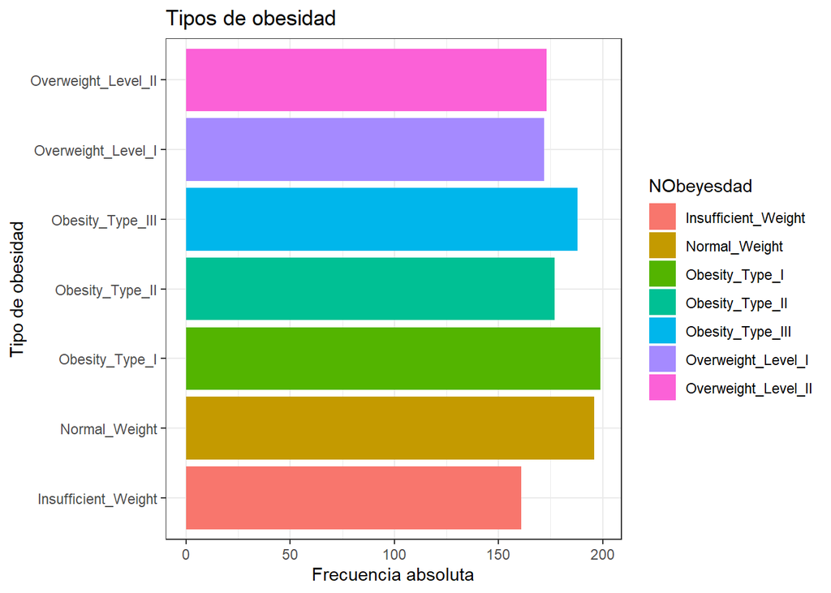

```r
train |>
  ggplot(aes(y = NObeyesdad, fill = NObeyesdad)) +
  geom_bar() +
  theme_bw() +
  labs(title = "Tipos de obesidad",
       y = "Tipo de obesidad",
       x = "Frecuencia absoluta")
```

Como se puede ver en el gráfico, la mayoría de las personas que hay en esta variable para entrenar nuestro modelo, han desarrollado obesidad de tipo I, siguiengo el peso normal y la obesidad de tipo III. A continuación, mostramos histogramas de todas las variables continuas y una matriz de correlación, aunque mas adelante analizaremos más detalladamente algunos de ellos.

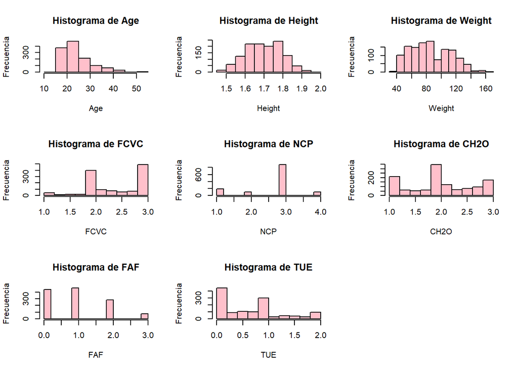

```r
df_continuas <- train[, sapply(train, is.numeric)]
# Histogramas de todas las variables continuas
par(mfrow = c(3, 3))  # Diseño de subgráficos
graficas <- lapply(names(df_continuas), function(var) {
  hist(df_continuas[[var]], main = paste("Histograma de", var),
       xlab = var, ylab = "Frecuencia", col = "pink")
})
```

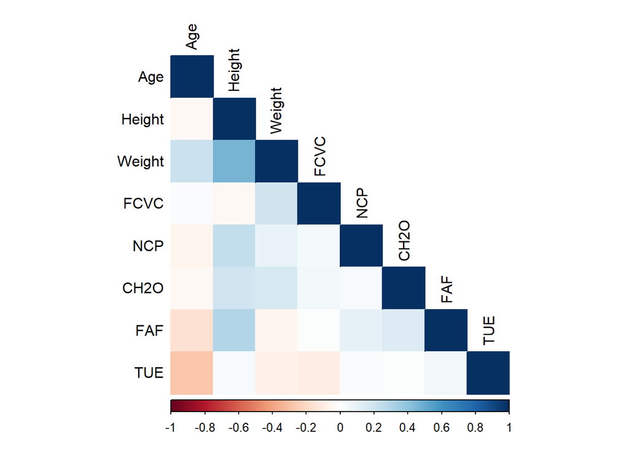

```r
# Matriz de correlación
cor_matrix <- cor(train %>% select_if(is.numeric))
corrplot(cor_matrix, method = "color", type = "lower", tl.col = "black")
```

Viendo esta matriz de correlaciones, podemos ver como la edad y el tiempo que se utilizan los dispositivos electrónicos, tiene una relación inversa, es decir, que cuanta más edad menos se usan, por otro lado, la altura tiene una relación con el número de comidas principales, el peso y la frecuencia de actividad física.Calculando la estadísticas descriptivas de las variables númericas obtenemos un resumen numérico de las características de los datos:

```r
#Estadísticas descriptivas de las variables númericas
df_continuas |>
  drop_na() |>
    descr()
```

```
## Descriptive Statistics
##
##                         Age      CH2O       FAF      FCVC    Height       NCP       TUE    Weight
## ----------------- --------- --------- --------- --------- --------- --------- --------- ---------
##              Mean     24.31      2.00      1.00      2.41      1.70      2.71      0.65     85.93
##           Std.Dev      6.37      0.62      0.90      0.54      0.09      0.81      0.61     26.13
##               Min     14.00      1.00      0.00      1.00      1.48      1.00      0.00     39.00
##                Q1     20.00      1.55      0.00      2.00      1.63      3.00      0.00     65.00
##            Median     23.00      2.00      1.00      2.35      1.70      3.00      0.59     82.33
##                Q3     26.00      2.46      2.00      3.00      1.77      3.00      1.00    106.53
##               Max     55.00      3.00      3.00      3.00      1.98      4.00      2.00    165.06
##               MAD      4.45      0.68      1.48      0.57      0.10      0.00      0.69     33.06
##               IQR      6.00      0.91      2.00      1.00      0.14      0.00      1.00     41.52
##                CV      0.26      0.31      0.91      0.22      0.06      0.30      0.93      0.30
##          Skewness      1.47     -0.10      0.51     -0.44     -0.03     -1.08      0.63      0.28
##       SE.Skewness      0.07      0.07      0.07      0.07      0.07      0.07      0.07      0.07
##          Kurtosis      2.36     -0.89     -0.67     -0.60     -0.63      0.48     -0.53     -0.74
##           N.Valid   1266.00   1266.00   1266.00   1266.00   1266.00   1266.00   1266.00   1266.00
##         Pct.Valid    100.00    100.00    100.00    100.00    100.00    100.00    100.00    100.00
```

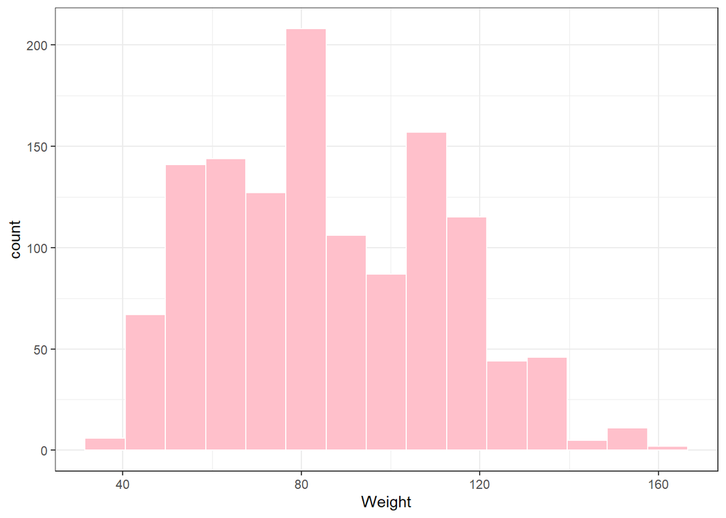

```r
train |> ggplot(aes(Weight)) +
  geom_histogram(
    fill = "pink",
    bins = 15,
    col = "white"
  ) +
  theme_bw()
```

Con la tabla de frecuencias podemos observar que el conjunto de datos tiene una distribución bastante parecida entre las categorías de obesidad, con la categoría Obesity Type l siendo la más frecuente (15.72%) y Insufficient Weight la menos frecuente (12.72%). Además, en el histograma de distribución del peso se aprecia un pico alrededor de los 80 kg, por lo que podemos intuir que las personas con Obesidad Tipo l pueden tener un peso alrededor de este valor. En general, los pesos se encuentran mayoritariamente entre los 50 y 120 kg y algún valor atípico por encima de los 160 kg. Ahora vamos a analizar las demás variables y su relación con otras variable. Lo primero que vamos a ver es la distribución del género en este estudio.

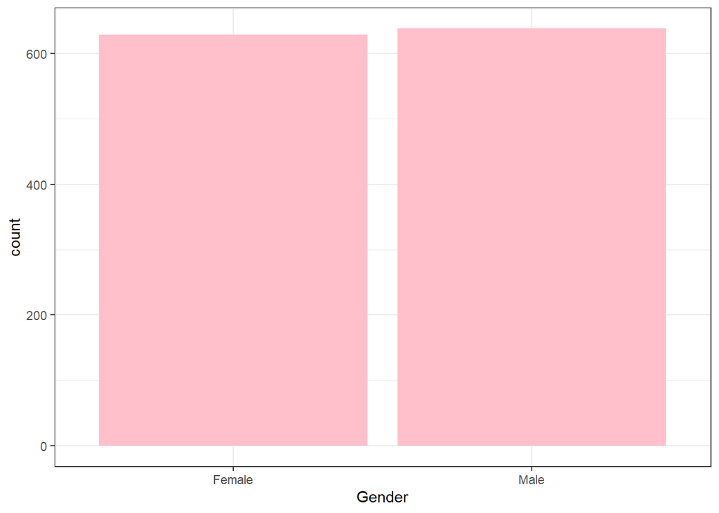

```r
train |>
  ggplot(aes(Gender)) +
  geom_bar(fill = "pink") +
  theme_bw()
```

Viendo el gráfico se puede ver que el número de mujeres y hombres que han participado en este estudio es bastante similar, lo que me da que pensar si el nivel de obesidad es más destacable con algún género.

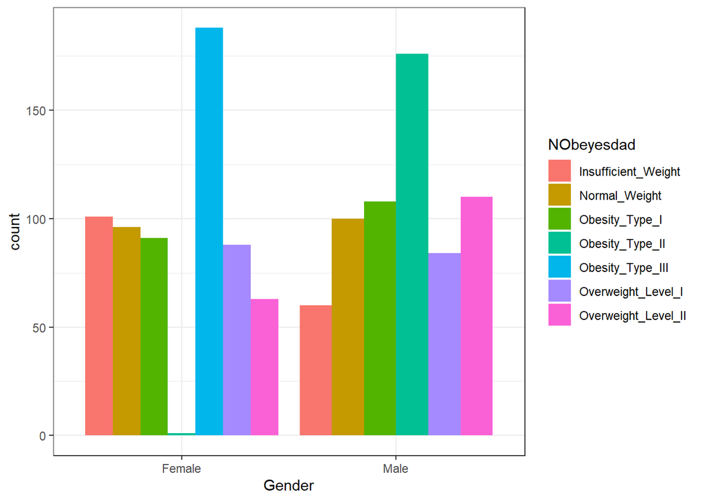

```r
train |>
  ggplot(aes(x = Gender, fill = NObeyesdad)) +
  geom_bar(position = "dodge") +
  theme_bw()
```

Al mirar la relación entre el nivel de obesidad entre hombres y mujeres, podemos ver com en mujeres se da sobre todo la obesidad de tipo III, mientras que en hombres la obesidad de tipo II, lo que si que es curioro es que en mujeres apenas hay con obesidad de tipo II y en hombre no hay personas con obesidad de tipo III. A continuación vamos a ver como se distribuye la edad de las personas del estudio

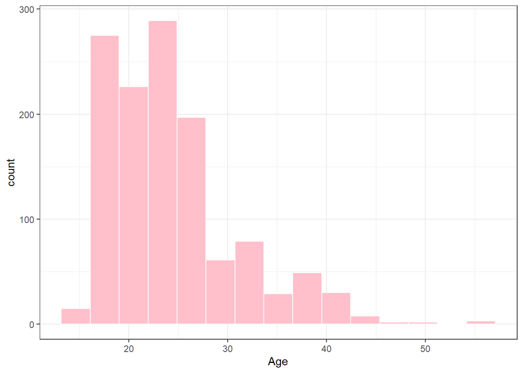

```r
train |>
  ggplot(aes(Age)) +
  geom_histogram(fill = "pink", col = "white", bins = 15) +
  theme_bw()
```

Por lo que se ve en este estudio han participado personas bastante jóvenes, ya que la mayoría de personas tienen entre 15 y 30 años, con un pico en los 20 años. A partir de los 30 años la frecuencia disminuye con muy pocos casos por encima de los 50 años, por ello vamos a ver que relación hay con el nivel de obesidad.

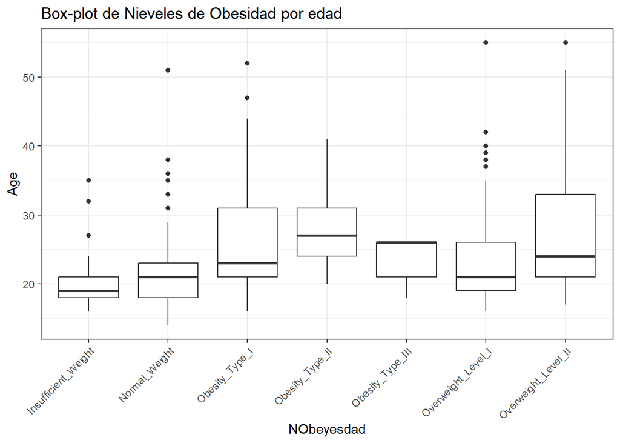

```r
train |>
  ggplot(aes(x = NObeyesdad , y = Age )) +
  geom_boxplot() +
  theme_bw() +
  labs(title = "Box-plot de Nieveles de Obesidad por edad")  +
  theme(axis.text.x = element_text(angle = 45, hjust = 1))
```

Los niveles de menor peso, Insufficient Weight y Normal Weight, tienen una mediana de edad más baja, entorno a los 20-25 años. Obesity Type l, Obesity Type ll y Obesity Type lll, tienen medianas de edad mas altas, entorno a los 25 años. Podemos observar también que Overweight Level ll tiene una variabilidad mayor en la edad. Encontramos valores atípicos que sobrepasan en la mayoría de categorías. De manera clara podemos concluir que las personas con menor peso tienden a ser más jóvenes, y las personas con un nivel de obesidad mayor tienen una media de edad más alta. Con estos datos más los de la matriz de correlación, vamos a ver la relación que hay entre la edad y el tiempo que se usan los dispositivos electrónicos.

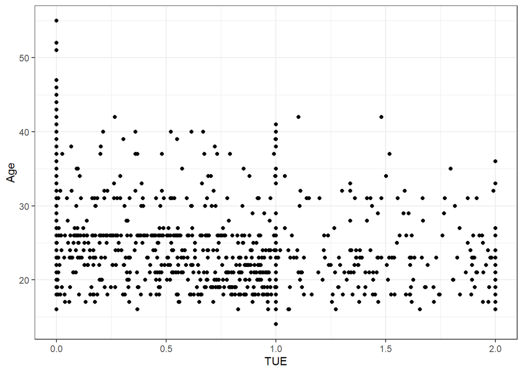

```r
train |>
  ggplot(aes(x = TUE, y = Age)) +
  geom_point() +
  theme_bw()
```

Por lo que vemos, hay una diferencia en la edad, lo que se puede ver que entre los 20 y los 30, hay más personas usando dispositivos electrónicos entre 0 y 2h, por otro lado, se ve como a partir de los 35 la gente usa menos el movil hasta los 45 que se ve que nadie lo usa.Ya vistos la edad y el género de las personas, vamos a ver la estatura de las personas.

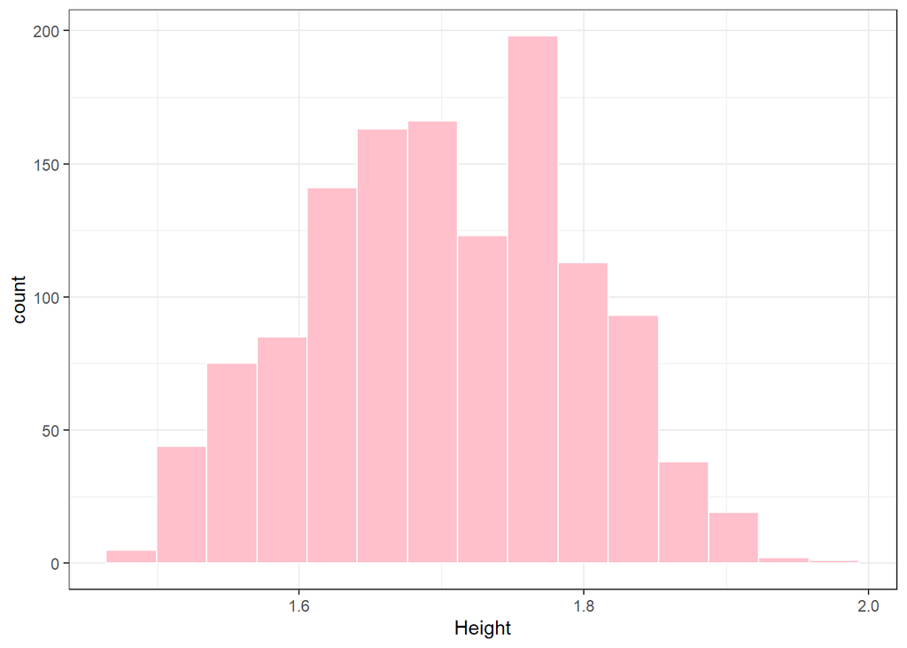

```r
train |>
  ggplot(aes(Height)) +
  geom_histogram(fill = "pink", bins = 15, col = "white") +
  theme_bw()
```

Este histograma muestra la distribución de alturas en la muestra, la mayoria de personas tienen una altura entre 1.60 y 1.90 metros, con un pico alrededor de los 1.75 y 1.80 metros. Esto tiene sentido, ya que teniendo en cuenta el histograma de edad, la mayoria de personas son jóvenes cuyas alturas suelen estar alrededor de estas. Lo que nos da que pensar la relación que puede haber con el peso y con el nivel de obesidad de las personas.

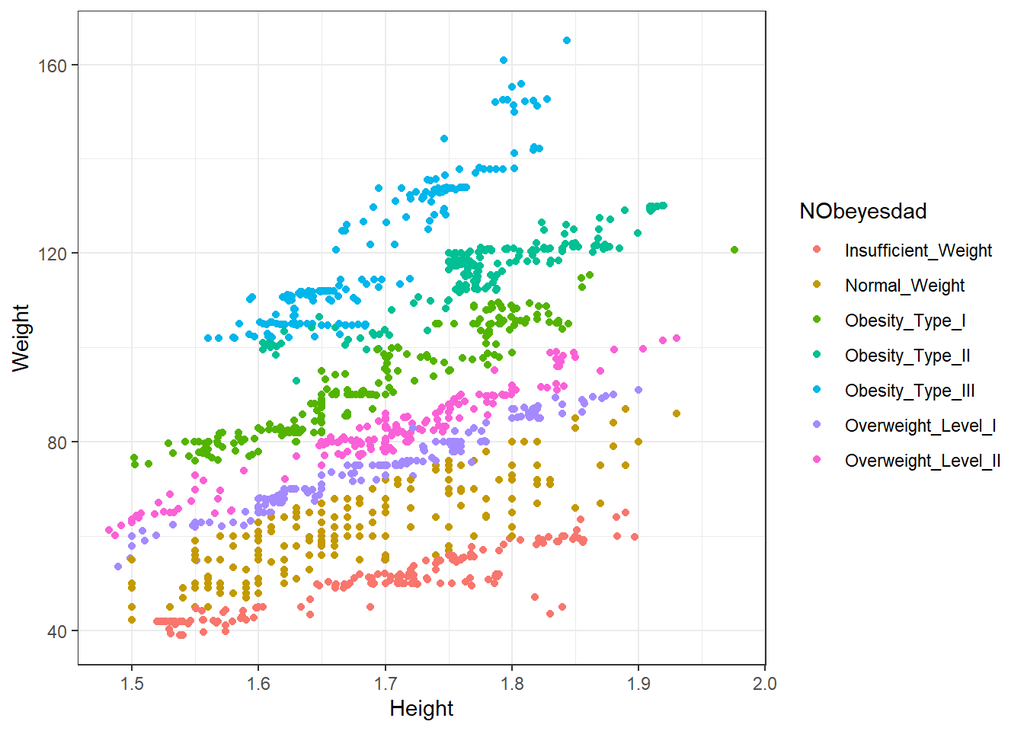

```r
train |>
  ggplot(aes(x = Height, y = Weight, color = NObeyesdad)) +
  geom_point() +
  theme_bw()
```

Como se ve hay una grán relación entre el peso, la altura y el nivel de obesidad, en la que cuanto más pesa y mide una personas, más posibilidad de desarrollar algún tipo de obesidad, como se ve, esta relación es lineal. Viendo este gráfico, vamos a representar el peso y la altura con el nivel de obesidad por separado.

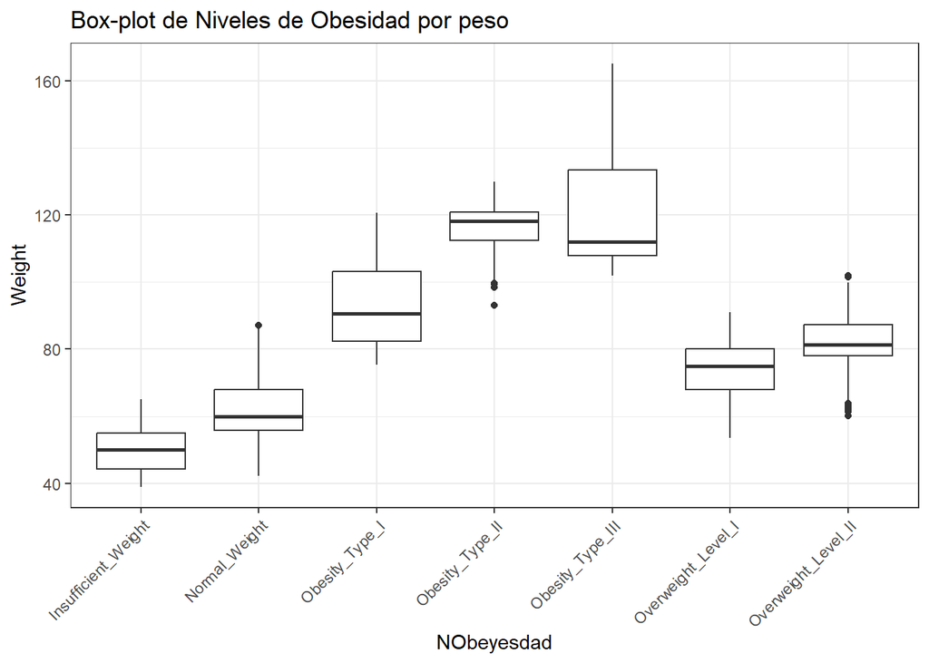

```r
train |>
  ggplot(aes(x = NObeyesdad , y = Weight)) +
  geom_boxplot() +
  theme_bw() +
  labs(title = "Box-plot de Niveles de Obesidad por peso") +
  theme(axis.text.x = element_text(angle = 45, hjust = 1))
```

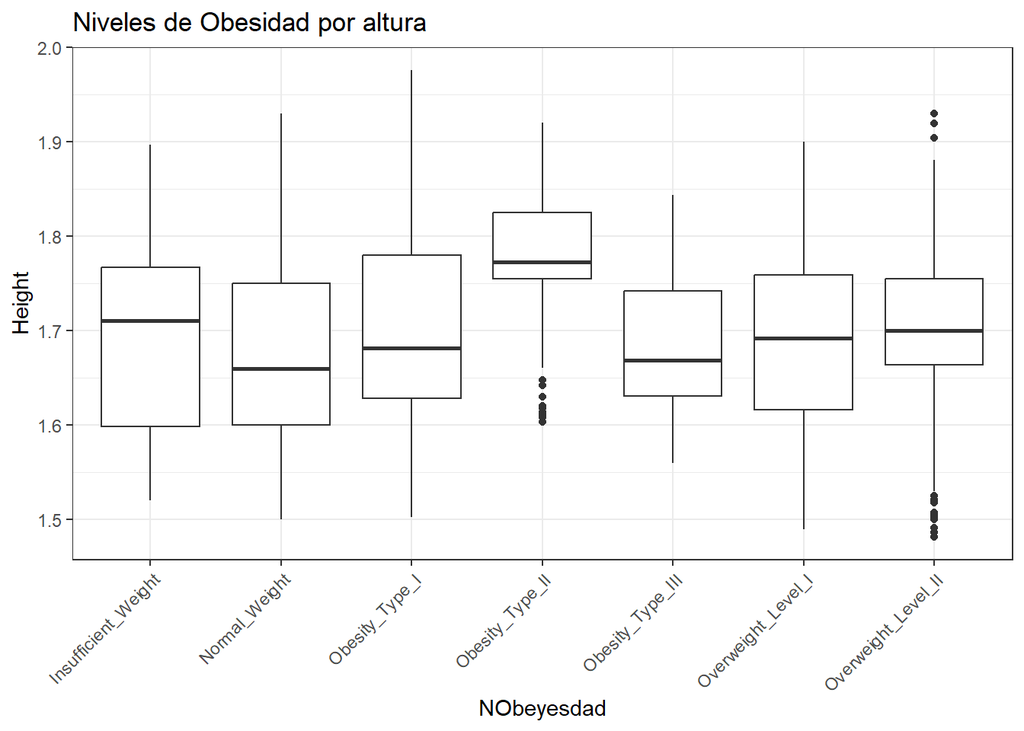

```r
train |>
  ggplot(aes(x = NObeyesdad , y = Height )) +
  geom_boxplot() +
  theme_bw() +
  labs(title = "Niveles de Obesidad por altura")  +
  theme(axis.text.x = element_text(angle = 45, hjust = 1))
```

Aunque algunas categoría presentan distribuciones más amplias no parece haber una diferencia muy grande entre la altura y los niveles de obesidad. Existen valores atípicos en las categorías Obesidad tipo ll (Obesity II ) y Sobrepeso tipo ll (Overweight ll), lo que significa que hay personas con alturas significativamente mas pequeñas a la mayoria de su grupo en el caso de Obesidad tipo ll y también mayores para Sobrepeso tipo ll. Ahora vamos a ver la relación con el número de comidas principales y con la frecuencia de actividad física.

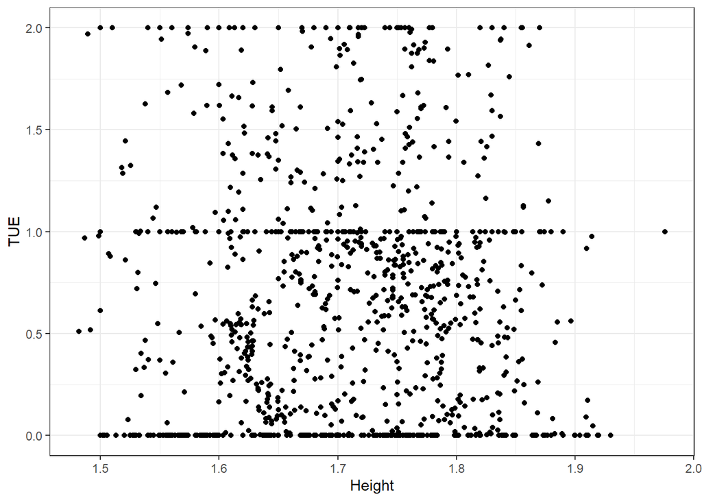

```r
train |>
  ggplot(aes(x = Height, y = TUE)) +
  geom_point() +
  theme_bw()
```

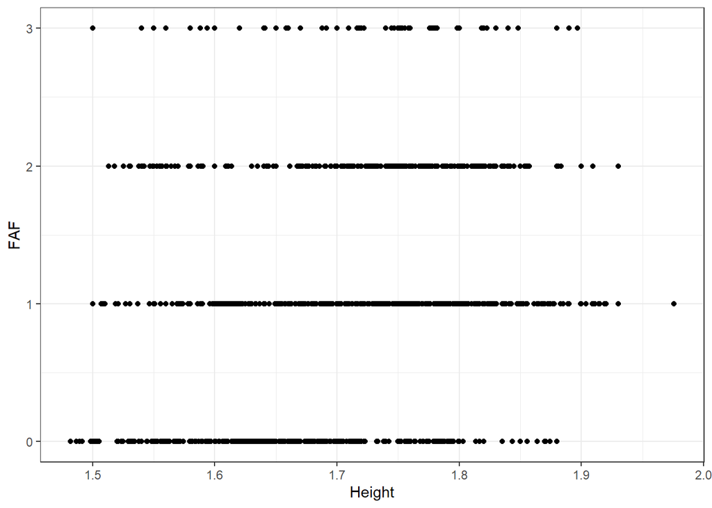

```r
train |>
  ggplot(aes(x = Height, y = FAF)) +
  geom_point() +
  theme_bw()
```

Con el gráfico de tiempo de uso de dispositovos electrónicos con la altura, no se ve ninguna relación, sin embargo, se puede ver que las personas que no hacen ejercicio miden menos que las que si que lo hacen, y que las personas que hacern ejercicio 1 día a la emana, la altura tiene mayor variabilidad que los que hacen ejercicio 2o 3 días a la semana. Con estos dos boxplots, podemos ver que se ve una relación grande entre el peso y el nivel de obesidad más que con la altura y el nivel de obesidad.

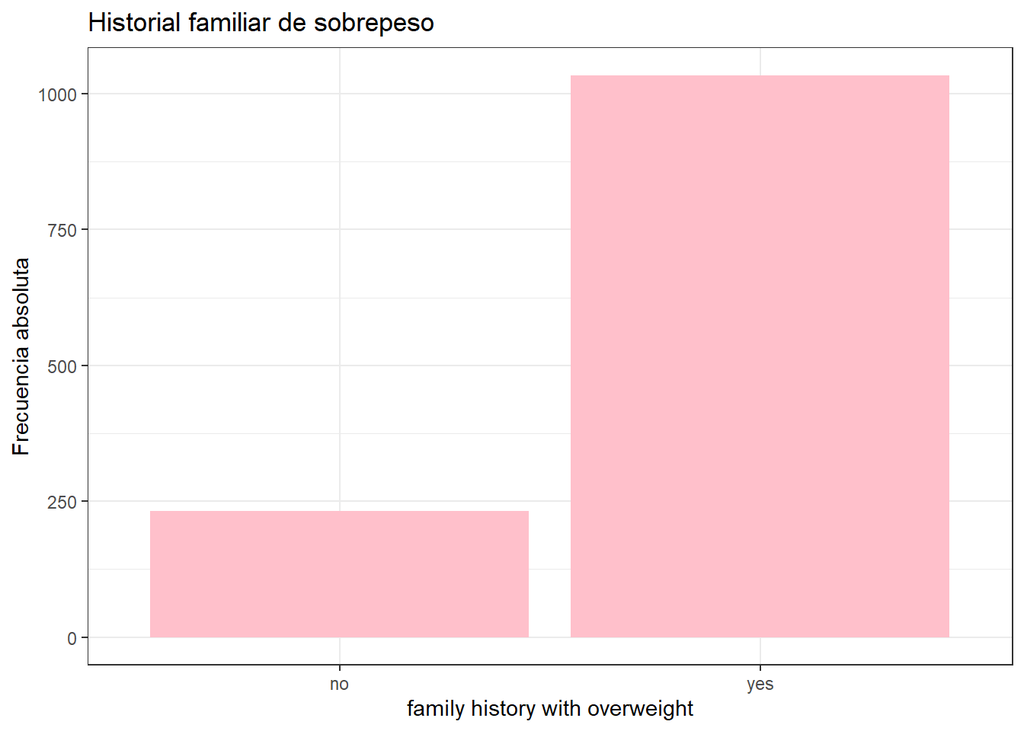

```r
train|>
  ggplot(aes(x = family_history_with_overweight)) +
  geom_bar(fill = "pink") +
  theme_bw() +
  labs(title = "Historial familiar de sobrepeso",
       x = "family history with overweight",
       y = "Frecuencia absoluta")
```

Muchas más personas tienen un historial familiar de sobrepeso de las que no lo tienen, por eso, vamos a ver si hay alguna relación con el nivel de obesidad y con el peso de las personas del estudio.

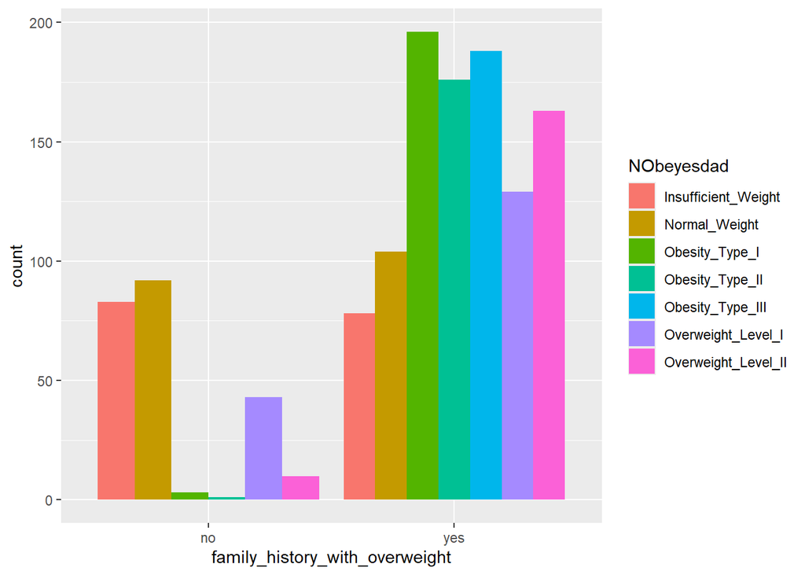

```r
train |>
  ggplot(aes(x = family_history_with_overweight, fill = NObeyesdad)) +
  geom_bar(position = "dodge")
```

Dado que la diferencia de personas en cada grupa es bastante diferente, vamos a hacer un gráfico individual para cada tipo de historial familiar.

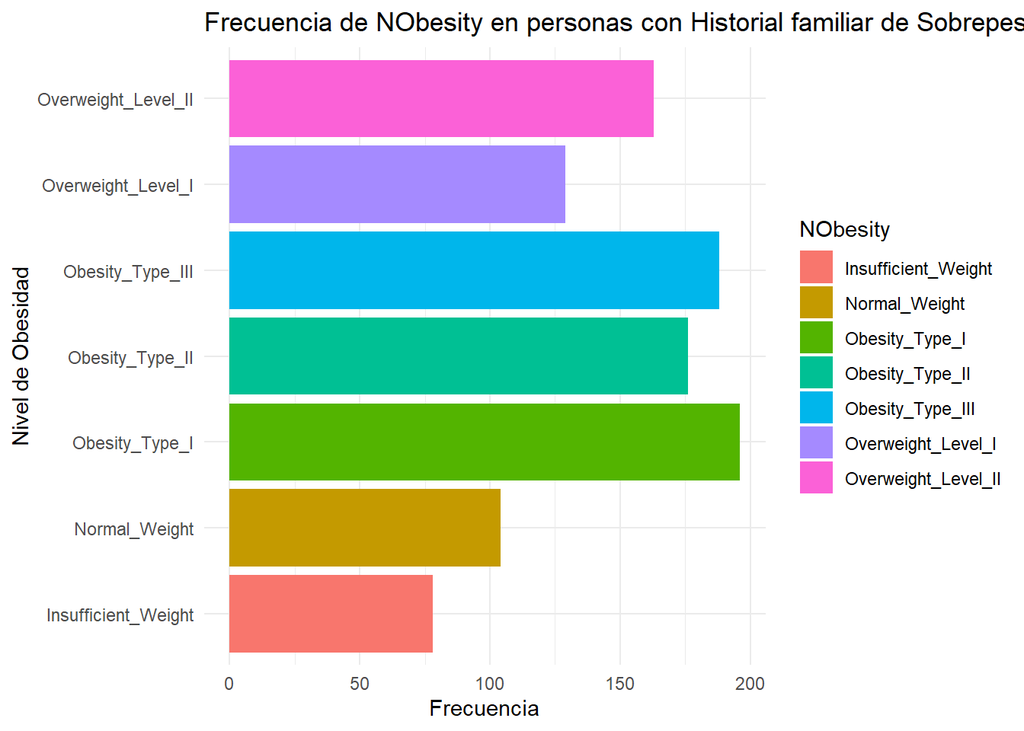

```r
ggplot(filter(train, family_history_with_overweight == "yes"), aes(y = NObeyesdad, fill = NObeyesdad)) +
  geom_bar(position = "dodge") +  # Barras separadas
  labs(y = "Nivel de Obesidad", x = "Frecuencia", fill = "NObesity") +
  ggtitle("Frecuencia de NObesity en personas con Historial familiar de Sobrepeso") +
  theme_minimal()
```

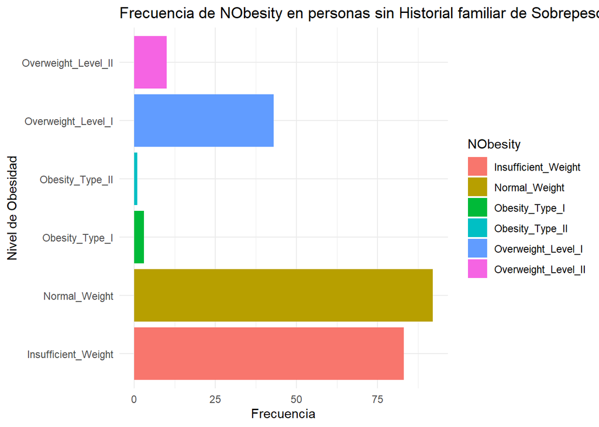

```r
# Filtrar datos donde la persona NO tiene historial familiar de sobrepeso
ggplot(filter(train, family_history_with_overweight == "no"), aes(y = NObeyesdad, fill = NObeyesdad)) +
  geom_bar(position = "dodge") +  # Barras separadas
  labs(y = "Nivel de Obesidad", x = "Frecuencia", fill = "NObesity") +
  ggtitle("Frecuencia de NObesity en personas sin Historial familiar de Sobrepeso") +
  theme_minimal()
```

El primer gráfico muestra los niveles de obesidad en personas con un historial familiar de obesidad, tal y como se puede observar, cuanto mayor es el nivel de obesidad, mas personas hay con familiares con obesidad. Ya que, las categorías “peso insuficiente” y “peso normal” son las que menos gente con este historial tienen, en las categorias de sobrepeso (Overweight) el número de personas con familiares con obesidad aumenta y ya por último en las de los tres tipos de obesidad, el número de mucho mayor.

En el segundo gráfico se muestra la otra categoria, pesonas sin historial familiar de sobrepeso. En este caso ocurre lo contrario, cuanto menor es el nivel de obesidad, mayor es la frecuencia con la no existe un historial familiar de sobrepeso. Cabe destacar que en los niveles de Obesidad 1 y 2, la frecuencia es casi nula y en el nivel de Obesidad 3 no hay frecuencia, por lo que no hay nadie con ese nivel de obesidad, que es el más alto, que no tenga un historial familiar de obesidad.

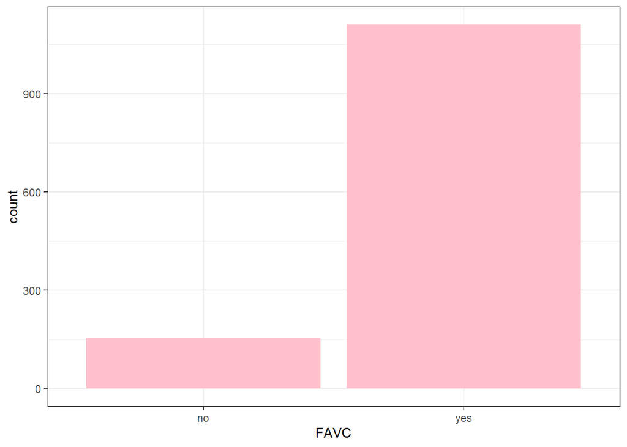

```r
train |>
  ggplot(aes(FAVC)) +
  geom_bar(fill = "pink") +
  theme_bw()
```

Por lo que se ve muchas de las personas consumen comidas con alto valor energético, por lo que hay que ver que realción tiene eso con el nivel de obesidad.

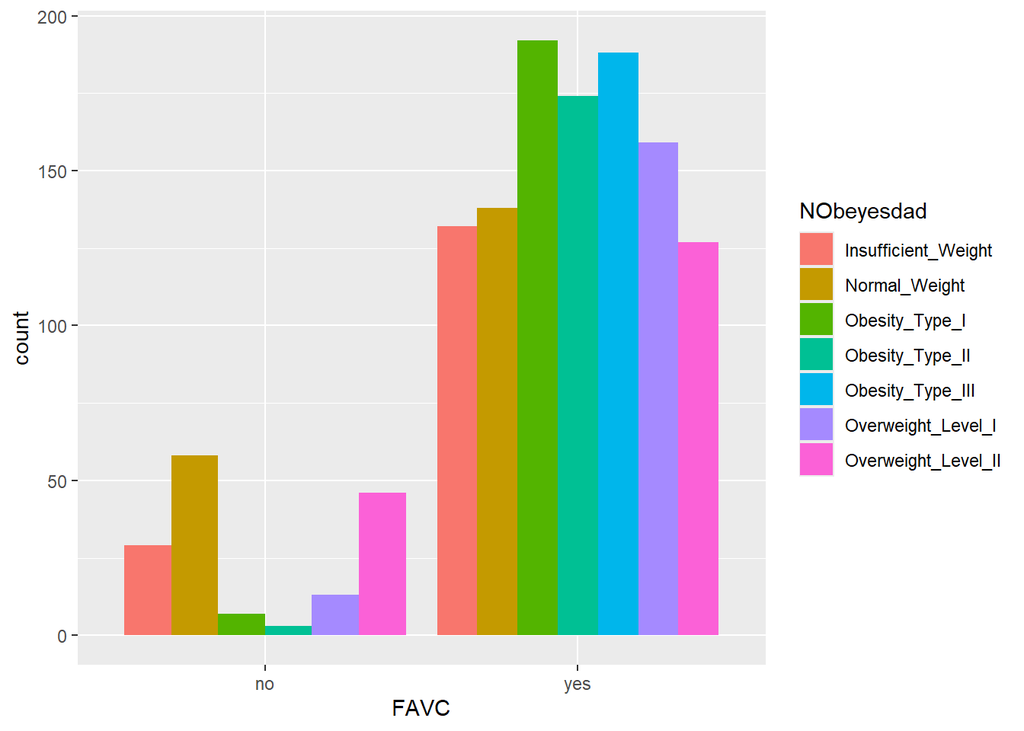

```r
train |>
  ggplot(aes(x = FAVC, fill = NObeyesdad)) +
  geom_bar(position = "dodge")
```

Por lo que se ve la mayoría de perosnas que consumen alimentos con un alto valor energético han desarrollado obesidad de tipo I, y la mayoría de personas que no consumen alimentos con un alto valor energético tienen un peso normal, por lo que necesitamos ver como se ve el peso según se consumen alimentos altos en calorias o no.

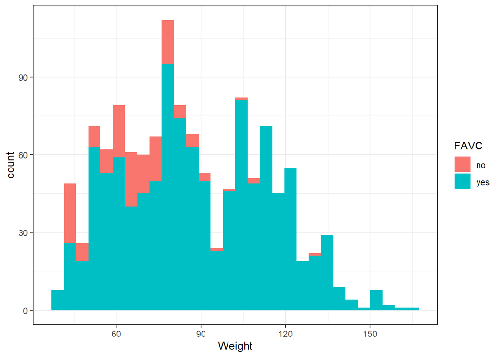

```r
train |>
  ggplot(aes(x = Weight, fill = FAVC)) +
  geom_histogram(bins = 30) +
  theme_bw()
```

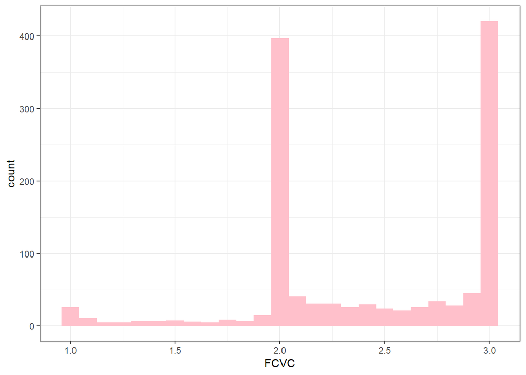

```r
train |>
  ggplot(aes(x = FCVC)) +
  geom_histogram(fill = "pink", bins = 25) +
  theme_bw()
```

Realizaremos un histograma de cada nivel de obesidad y su disatribución del consumo de vegetales para que sea mas claro, ya que al ser varios niveles en un mismo histrograma no se ve con claridad.

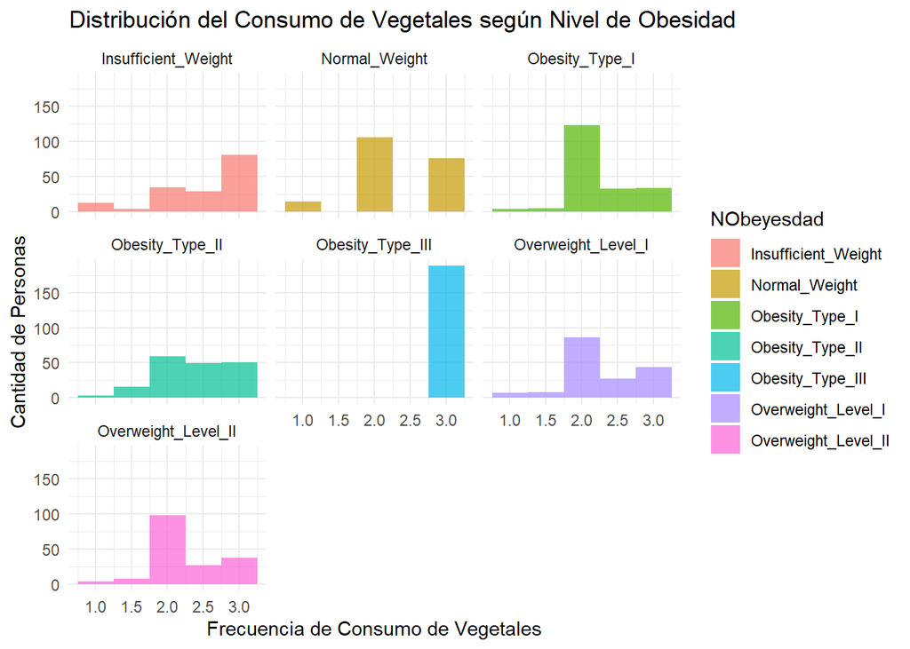

```r
ggplot(train, aes(x = FCVC, fill = NObeyesdad)) +
  geom_histogram(binwidth = 0.5, alpha = 0.7, position = "identity") +
  facet_wrap(~NObeyesdad) +
  labs(x = "Frecuencia de Consumo de Vegetales", y = "Cantidad de Personas",
       title = "Distribución del Consumo de Vegetales según Nivel de Obesidad") +
  theme_minimal()
```

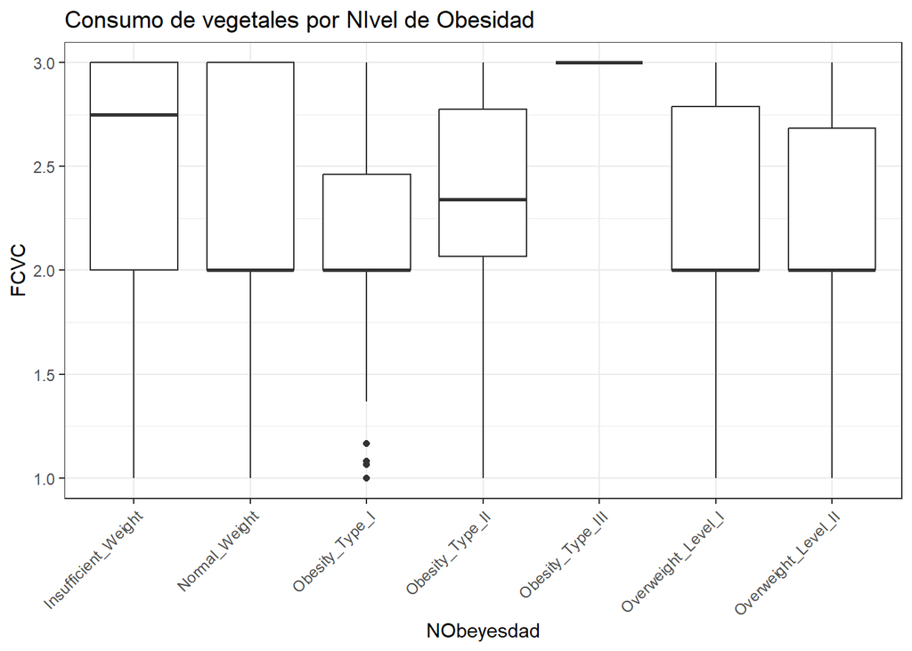

```r
train |>
  ggplot(aes(x = NObeyesdad, y = FCVC)) +
  geom_boxplot() +
  theme_bw() +
  labs(title = "Consumo de vegetales por NIvel de Obesidad") +
  theme(axis.text.x = element_text(angle = 45, hjust = 1))
```

Viendo este boxplot, puedo ver que la frecuencia de consumo de verduras, está en torno a 2

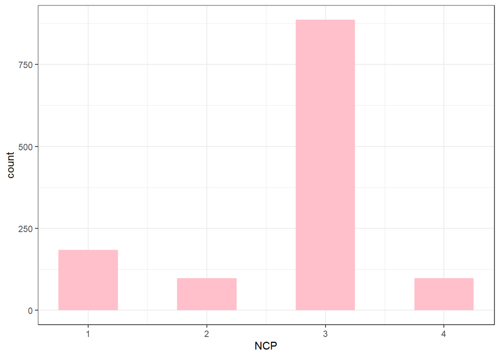

```r
train |>
  ggplot(aes(x = NCP)) +
  geom_histogram(fill = "pink", bins = 7) +
  theme_bw()
```

Con este diagrama de barras, se puede ver com la mayoría de las personas hacen 3 comidas principales al día, por lo que nos surge la duda de si tiene alguna relación con el nivel de obesidad y con el peso.

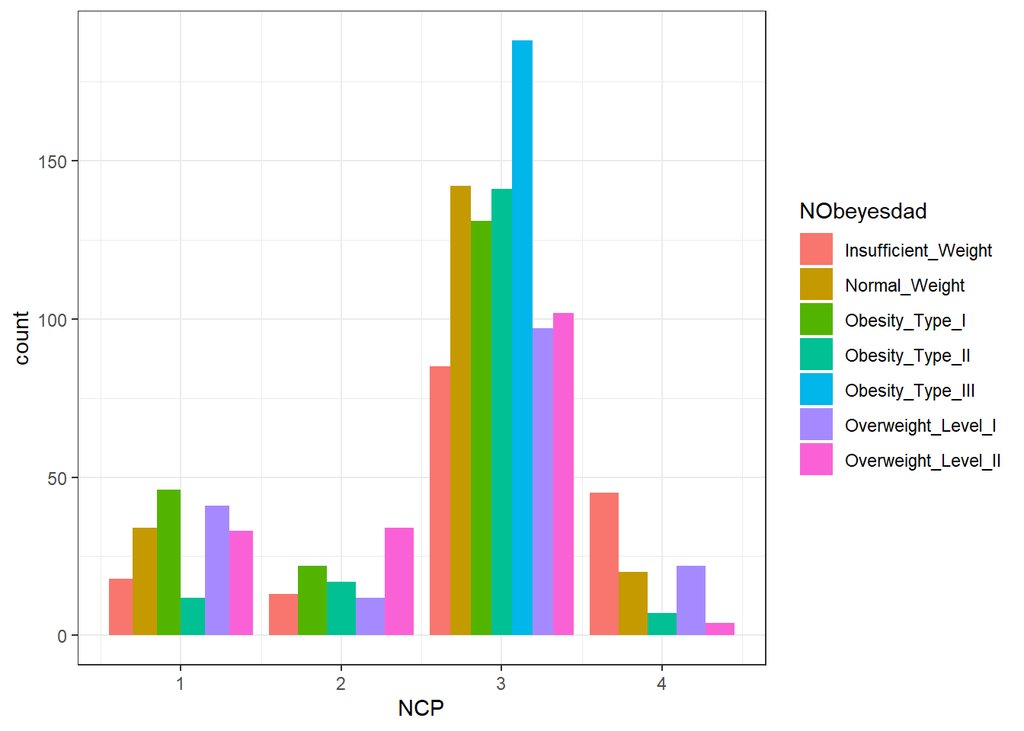

```r
train |>
  ggplot(aes(x = NCP, fill = NObeyesdad)) +
  geom_bar(position = "dodge") +
  theme_bw()
```

En nuestro estudio, se ve como el nivel de obesidad no tiene mucho que ver, ya qeu hay personas con peso insuficiente que hacer 4 comidas al día o que hay personas que haciendo una comida al día han desarrollado obesidad de tipo I.

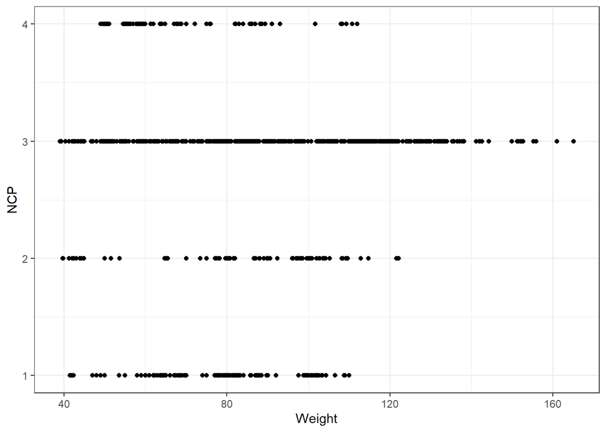

```r
train |>
  ggplot(aes(x = Weight, y = NCP)) +
  geom_point() +
  theme_bw()
```

Con estos gráficos, se puede concluir lo que ya se ha visto con el número de comidas principales que hay, y es que la mayoría de las personas hacen 3 comidas principaes al día, además de eso, se ve como donde más varía el peso de las personas es con 3 comidas al día, ya que es donde más concentración de personas hay ahí. Ahora vamos a ver el consumo de alimentos entre comidas de las personas.

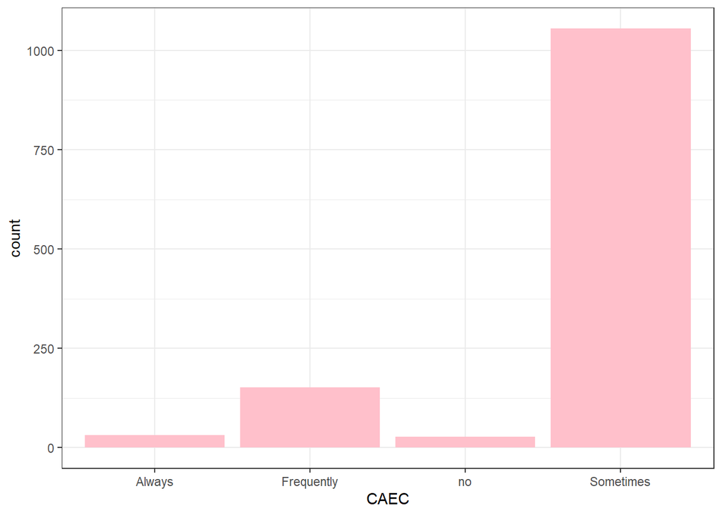

```r
train |>
  ggplot(aes(x = CAEC)) +
  geom_bar(fill = "pink") +
  theme_bw()
```

Vemos que muchas personas comen entre comidas esporádicamente, por ello vamos a compararlo con el nivel de obesidad.

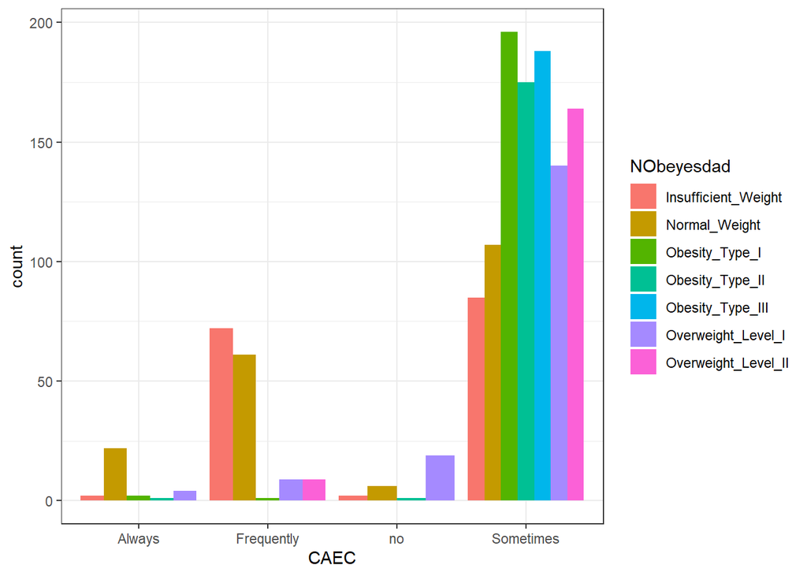

```r
train |>
  ggplot(aes(x = CAEC, fill = NObeyesdad)) +
  geom_bar(position = "dodge") +
  theme_bw()
```

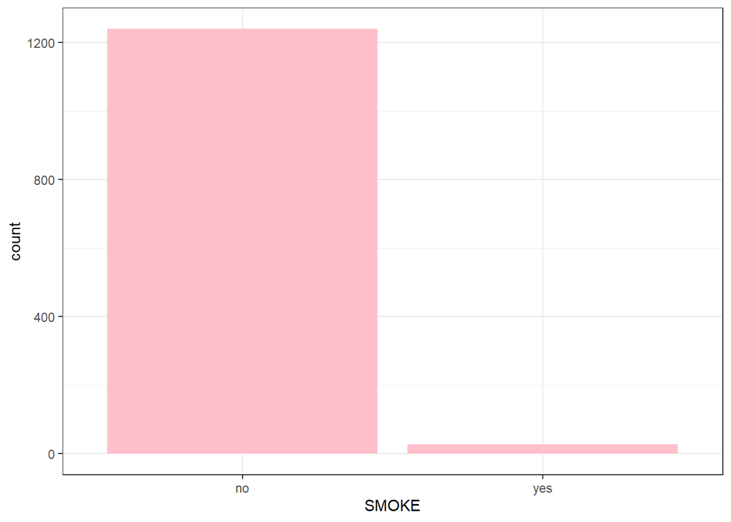

```r
train |>
  ggplot(aes(x = SMOKE)) +
  geom_bar(fill = "pink") +
  theme_bw()
```

Por lo que se ve la mayoría de las personas no fuman, sin embargo, me gustaría ver esta variable dependiendo de si hacen ejercicio o no y del nivel de obesidad de las personas.

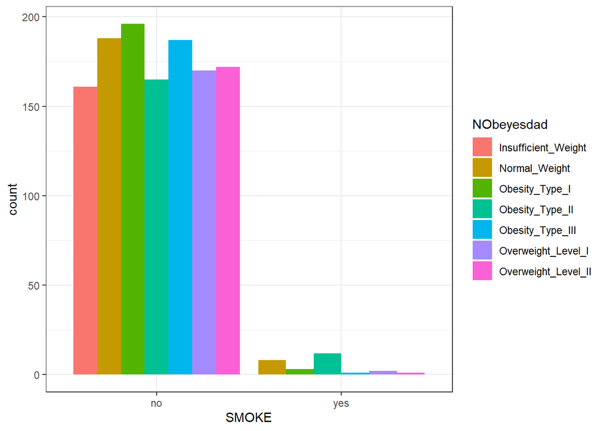

```r
train |>
  ggplot(aes(x = SMOKE, fill = NObeyesdad)) +
  geom_bar(position = "dodge") +
  theme_bw()
```